# How to map data using R

We will look at two situations where we have data with information we might like to map:

1. the data contains coordinates e.g. longitude and latitude
2. the data contains geographical names e.g. continents, countries, counties, states or regions

Within each will we look at two methods to plot maps of the data using R:

1. interactive maps using `leaflet`
2. static maps using `ggplot2`

Each workflow (1) and (2) follows a similar process - we need to match the location data in our data with spatial data that we can use to map.

## 1. Mapping data from coordinates

If we have data that has coordinates contained within it, this can be more straightforward to plot then when we have area names. To demonstrate, we’ll simulate a data frame that contains longitude and latitude of places within Ireland, and an associated value we want to map for each location:

```r
# create data frame for locations in Ireland
coord_data <- data.frame(
  longitude = c(-6.2603, -8.4735, -9.0568, -8.6305, -7.1101,
                -7.2491, -8.4761, -7.9408, -6.4577, -9.7111),
  latitude  = c(53.3498, 51.8985, 53.2707, 52.6638, 52.2593,
                52.6541, 54.2697, 53.4239, 52.3369, 52.2713),
  value     = c(120, 95, 78, 60, 45, 55, 40, 50, 42, 38)
)

# view the data frame
coord_data
```

```
##    longitude latitude value
## 1    -6.2603  53.3498   120
## 2    -8.4735  51.8985    95
## 3    -9.0568  53.2707    78
## 4    -8.6305  52.6638    60
## 5    -7.1101  52.2593    45
## 6    -7.2491  52.6541    55
## 7    -8.4761  54.2697    40
## 8    -7.9408  53.4239    50
## 9    -6.4577  52.3369    42
## 10   -9.7111  52.2713    38
```

For an interactive `leaflet` map we don’t need to do anything more with the data as we already have coordinates that can be used for mapping the values. For a static map in `ggplot2` we’ll need to also include geometry details of a map of Ireland to map the values on to.

### (a) Interactive maps using leaflet

Using the `leaflet` package we can create engaging detailed interactive maps. As our example data,`coord_data`, already includes longitude or latitude information we can use the data directly with `leaflet` functions.

We need to use the `addTiles()` function from `leaflet` to add a background map layer; by default this uses OpenStreetMap. Then using `addMarkers()` function we can add location markers to the `leaflet` map and also add a label for the variable(s) in our data we want to display:

```r
library(leaflet)

# create a leaflet map with location markers
leaflet(coord_data) %>%  # add in data frame
  addTiles() %>%
  addMarkers(
    lng   = ~longitude, # location variables from data
    lat   = ~latitude,
    label = ~paste0("Value: ", value) # value variable from data
  )
```

[interactive chart not shown]

This produces an interactive HTML widget where users can zoom, pan, and hover over markers to see labels/values. It’s great for web pages, R Markdown/Quarto documents, or Shiny apps. As the output is an HTML file and not a static image, it doesn’t suit print or PDF workflows directly, though a screen shot for example could be used.

Instead of location markers, we could use `addCircleMarkers()` function to add circle markers that we can colour according to a variable value. Note we need to define the colour palette separately first:

```r
# define colour palette
pal1 <- colorNumeric("PiYG", domain = coord_data$value)

# create a leaflet map using circle markers and colour for values
leaflet(coord_data) %>%
  addTiles() %>%
  addCircleMarkers(
    lng         = ~longitude,
    lat         = ~latitude,
    fillColor   = ~pal1(value),
    fillOpacity = 1,
    color       = "white",
    weight      = 1,
    label       = ~paste0("Value: ", value)
  ) %>%
  addLegend(pal = pal1, values = ~value, title = "Value")
```

[interactive chart not shown]

We could set the size of the circles to match our data instead (or as well):

```r
# create a leaflet map using circle markers and size for values
leaflet(coord_data) %>%
  addTiles() %>%
  addCircleMarkers(
    lng         = ~longitude,
    lat         = ~latitude,
    radius      = ~scales::rescale(value, to = c(5, 25)), # note adjust scale
    fillColor   = "steelblue",
    fillOpacity = 0.8,
    weight      = 1,
    label       = ~paste0("Value: ", value)
  )
```

[interactive chart not shown]

### (b) Static maps using ggplot2

If we want to create static images instead, we can use the `geom_sf()` function within `ggplot2` to plot a map of our data.

First, we’ll need to add a column with geometry information to produce a geospatial object, an `sf` object. `sf` stands for “simple features”, it’s an open international standard (ISO 19125) for representing real-world geographic objects in software. The “simple” refers to the fact that shapes are represented as straight lines and points rather than curves, which keeps the geometry computationally straightforward.

To convert our data into an `sf` object we’ll use the `st_as_sf` function from the `sf` package. Within the function we need to specify what coordinate reference system (crs) we’re using, we have longitude and latitude so we specify `crs = 4326`; this is the standard longitude and latitude used by GPS and most web data (note other options are available).

```r
library(sf)

# retrieve sf object of the example data
points_sf <- st_as_sf(coord_data, coords = c("longitude", "latitude"), crs = 4326)
```

This gives us the `sf` object we need as a data frame:

```r
str(points_sf)
```

```
## Classes 'sf' and 'data.frame':   10 obs. of  2 variables:
##  $ value   : num  120 95 78 60 45 55 40 50 42 38
##  $ geometry:sfc_POINT of length 10; first list element:  'XY' num  -6.26 53.35
##  - attr(*, "sf_column")= chr "geometry"
##  - attr(*, "agr")= Factor w/ 3 levels "constant","aggregate",..: NA
##   ..- attr(*, "names")= chr "value"
```

We also need a map of Ireland with the counties onto which we can map our data points. We can use the `rnaturalearth` package to retrieve geospatial data for the Irish counties. From this libraries we use the `ne_states()` function to retrieve the geometry data we need.

```r
library(rnaturalearth)

# retrieve provinces/regions sf object
counties_sf <- ne_states(country = "Ireland", returnclass = "sf")
```

Then we can use the `geom_sf()` function within `ggplot2` to plot our data `points_sf` on the map of Ireland object `counties_df`. `geom_sf()` treats the map just like any other `ggplot2` layer, so all the usual `ggplot2` customisation applies - themes, fonts, colour scales, faceting, labelling etc.

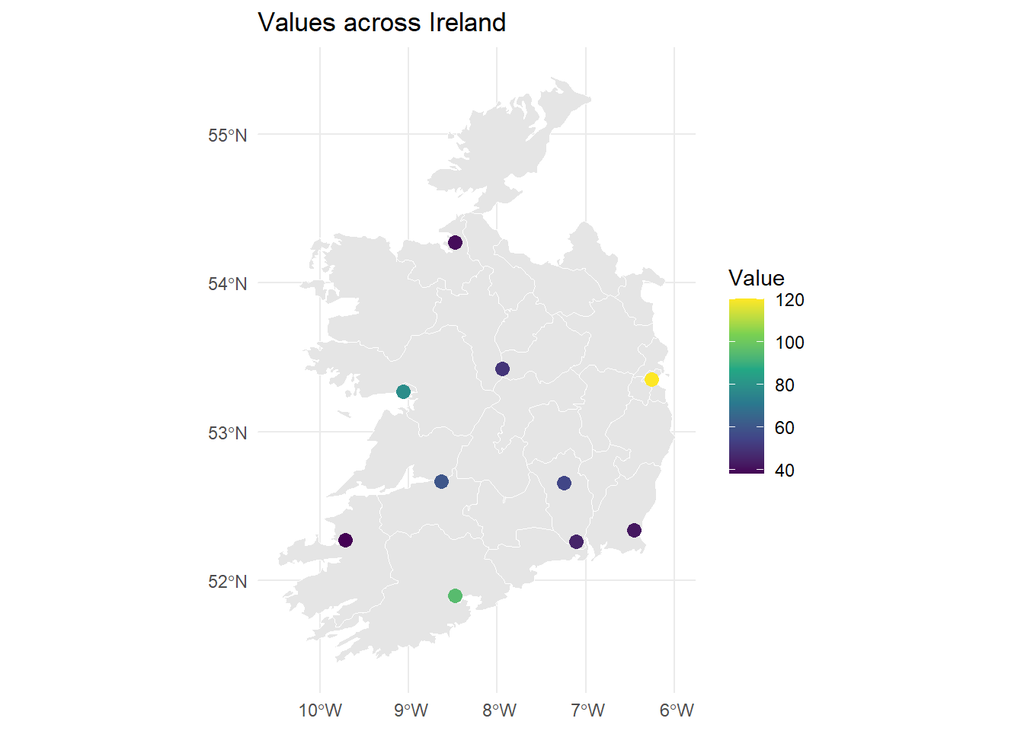

```r
# plot value data onto map of Irish counties
ggplot() +
  # Ireland outline as background
  geom_sf(data = counties_sf, , fill = "grey90", color = "white") +
  # plot points using colour to encode the value
  geom_sf(data = points_sf, aes(colour = value), size = 3) +
  # add customisation such as colour scale, labelling and theme:
  scale_color_viridis_c(option = "D") +
  labs(title = "Values across Ireland", color = "Value") +
  theme_minimal()
```

This produces a static image (PNG/PDF/SVG etc.) suitable for reports, papers, or publications which is easy to export using `ggsave()` for example.

## 2. Mapping data from geographical names

We can also use data that contains geographical names such as continents, countries, counties, states or regions. First lets simulate a data frame that contains county of Ireland names, and an associated value we want to map for each county:

```r
# create data frame of county level data
county_data <- data.frame(
  county = c("Carlow", "Cavan", "Clare", "Cork", "Donegal",
             "Dublin", "Galway", "Kerry", "Kildare", "Kilkenny",
             "Laois", "Leitrim", "Limerick", "Longford", "Louth",
             "Mayo", "Meath", "Monaghan", "Offaly", "Roscommon",
             "Sligo", "Tipperary", "Waterford", "Westmeath", "Wexford", "Wicklow"),
  value = c(42, 17, 63, 88, 34,
            95, 71, 55, 80, 29,
            38, 12, 67, 23, 74,
            46, 83, 31, 44, 19,
            58, 62, 77, 36, 69, 91))
# view the data frame
county_data
```

```
##       county value
## 1     Carlow    42
## 2      Cavan    17
## 3      Clare    63
## 4       Cork    88
## 5    Donegal    34
## 6     Dublin    95
## 7     Galway    71
## 8      Kerry    55
## 9    Kildare    80
## 10  Kilkenny    29
## 11     Laois    38
## 12   Leitrim    12
## 13  Limerick    67
## 14  Longford    23
## 15     Louth    74
## 16      Mayo    46
## 17     Meath    83
## 18  Monaghan    31
## 19    Offaly    44
## 20 Roscommon    19
## 21     Sligo    58
## 22 Tipperary    62
## 23 Waterford    77
## 24 Westmeath    36
## 25   Wexford    69
## 26   Wicklow    91
```

As we saw in section (1), we’ll need to add a column with geometry information to produce a geospatial object, an `sf` object. Using the `rnaturalearth` package we will use the `ne_states()` function to retrieve the data for the Irish counties (or states as they are referred to in the package).

```r
library(rnaturalearth)

# retrieve regions sf object
counties_sf <- ne_states(country = "Ireland", returnclass = "sf")
```

This gives us the `sf` object we need as a data frame:

```r
class(counties_sf)
```

```
## [1] "sf"         "data.frame"
```

```r
#str(counties_sf) # uncomment this to view the object
```

We can then inspect the `counties_sf` object and find which element refers to the county names, and then view the counties to check they match our data.

```r
sort(counties_sf$name)
```

```
##  [1] "Carlow"                 "Cavan"                  "Clare"
##  [4] "Cork"                   "Cork"                   "Donegal"
##  [7] "Dublin"                 "Dún Laoghaire–Rathdown" "Fingal"
## [10] "Galway"                 "Galway"                 "Kerry"
## [13] "Kildare"                "Kilkenny"               "Laoighis"
## [16] "Leitrim"                "Limerick"               "Limerick"
## [19] "Longford"               "Louth"                  "Mayo"
## [22] "Meath"                  "Monaghan"               "North Tipperary"
## [25] "Offaly"                 "Roscommon"              "Sligo"
## [28] "South Dublin"           "South Tipperary"        "Waterford"
## [31] "Waterford"              "Westmeath"              "Wexford"
## [34] "Wicklow"
```

Now we can add the `sf` object, `counties_sf`, to the data that we want to visualise, `county_data`. We use a `left_join()` to match each row in the spatial `sf` object to its corresponding row in `county_data` by county name, retaining all counties from `counties_sf` regardless of whether a match is found in `county_data`. This gives us a single object containing both the geometry needed to draw the map and the values we want to display.

```r
# join your data to the spatial object
ireland_map <- counties_sf %>%
  left_join(county_data, by = c("name" = "county"))  # adjust column names as needed - check the sf object

class(ireland_map)
```

```
## [1] "sf"         "data.frame"
```

We can now check that we have the counties and associated data `value` contained within the `sf` object, `ireland_map`. The counties will be referred to by whatever variable name they were called in the `counties_sf` object, `name` in this case.

```r
# check columns of interest
ireland_map %>% select(c(name, value))
```

```
## Simple feature collection with 34 features and 2 fields
## Geometry type: MULTIPOLYGON
## Dimension:     XY
## Bounding box:  xmin: -10.47818 ymin: 51.44571 xmax: -5.99352 ymax: 55.38638
## Geodetic CRS:  WGS 84
## First 10 features:
##                      name value                       geometry
## 1                 Donegal    34 MULTIPOLYGON (((-7.2471 55....
## 2                 Leitrim    12 MULTIPOLYGON (((-8.168467 5...
## 3                   Cavan    17 MULTIPOLYGON (((-7.942075 5...
## 4                Monaghan    31 MULTIPOLYGON (((-7.017836 5...
## 5                   Louth    74 MULTIPOLYGON (((-6.605217 5...
## 6                  Dublin    95 MULTIPOLYGON (((-6.14977 53...
## 7  Dún Laoghaire–Rathdown    NA MULTIPOLYGON (((-6.180536 5...
## 8                 Wicklow    91 MULTIPOLYGON (((-6.088938 5...
## 9                 Wexford    69 MULTIPOLYGON (((-6.151031 5...
## 10               Kilkenny    29 MULTIPOLYGON (((-6.994496 5...
```

We can see we have the `name` of the county, the `value` variable and then there’s associated `geometry` information that will be used to map the data.`NA`s will be added anywhere we don’t have data corresponding to particular regions.

### (a) Interactive maps using leaflet

Using the `leaflet` package we can create detailed interactive maps. As before we use `addTiles()` function from `leaflet` to add a background map layer. Then instead of defining markers for the data as we did in part (1) we need to use `addPolygons()` function to define shapes to represent the geographical regions. We also define a colour palette to fill the polygons based on whatever variables values we are displaying.

```r
library(leaflet)

# specify a colour palette to use
pal <- colorNumeric("YlOrRd", domain = ireland_map$value)

# create the leaflet map using polygons
leaflet(ireland_map) %>%
  addTiles() %>%
  addPolygons( # use polygons instead of markers
    fillColor = ~pal(value),
    fillOpacity = 0.7,
    color = "white", weight = 1,
    label = ~paste0(name, ": ", value)
  ) %>%
  addLegend(pal = pal, values = ~value, title = "Value")
```

[interactive chart not shown]

This produces an interactive HTML widget where users can zoom, pan, and hover over counties to see labels and values.

### (b) Static maps using ggplot2

We have already set up our data to contain the geometry information we need to use `geom_sf()` function within `ggplot2` to plot a map of our data.

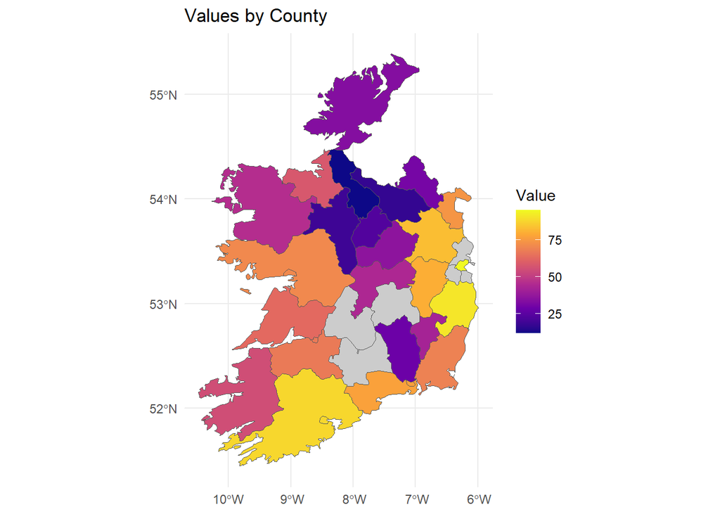

```r
library(ggplot2)

# plot the value variable according to county
ggplot(ireland_map) +
  geom_sf(aes(fill = value)) +
  #add customisation such as colour scale, labelling and theme:
  scale_fill_viridis_c(option = "plasma", na.value = "grey80") +
  labs(title = "Values by County", fill = "Value") +
  theme_minimal()
```

This type of map is also known as a choropleth map, where the region polygons are filled by a data value.

All the styling options available to `ggplot2` can be used in the map plot, for example:

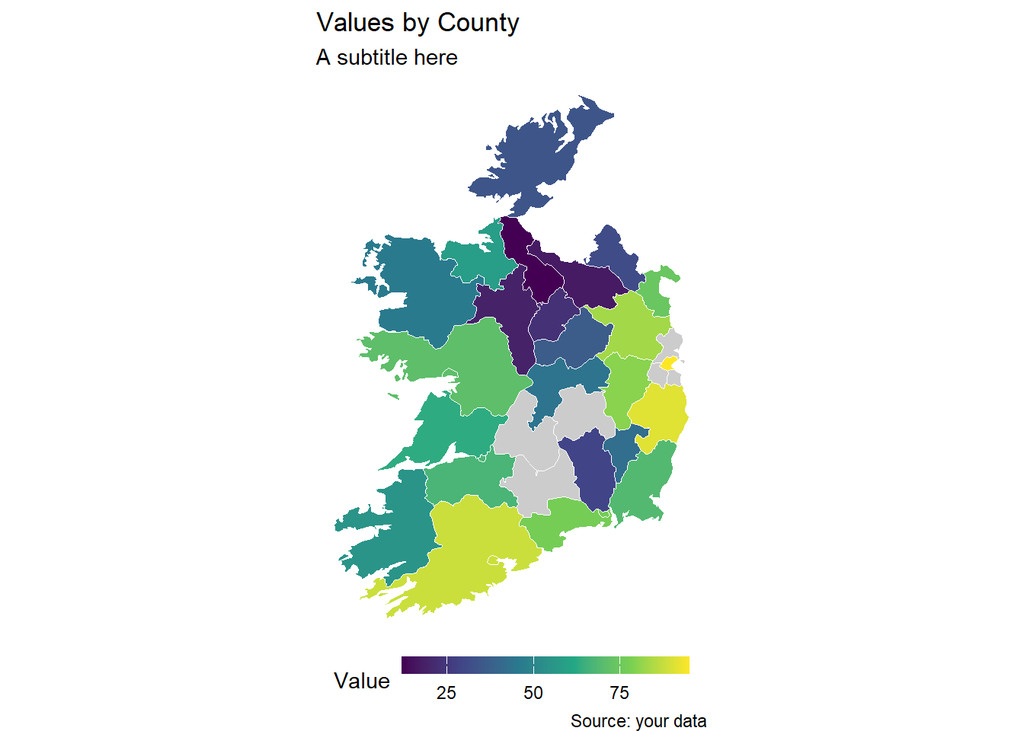

```r
# replot and change styling
ggplot(ireland_map) +
  geom_sf(aes(fill = value), colour = "white") +
  scale_fill_viridis_c(option = "viridis", na.value = "grey80") +
  labs(
    title    = "Values by County",
    subtitle = "A subtitle here",
    caption  = "Source: your data",
    fill     = "Value"
  ) +
  theme_void() +   # removes axes, ticks, and gridlines
  theme(
    # legend styling
    legend.position      = "bottom",
    legend.key.width     = unit(1, "cm"),      # make the bar wider
    legend.key.height    = unit(0.3, "cm"),    # make the bar thinner
  )
```

## Further information

In all our examples we have used counties of Ireland, but you can follow the same steps to map values to countries of the world, states of the US or continents for example.

The R community has many many resources on helping users make beautiful functional maps in R. Here are just a few places to get started:

- The [R-Graph Gallery](https://r-graph-gallery.com/map.html) is always a good place to start with data visualisation, and it has many mapping options including more details and examples of using `ggplot2` and `leaflet`.
- The [leaflet page on R-Graph Gallery](https://r-graph-gallery.com/package/leaflet.html) is a good place to start if you want more examples and details of using leaflet for mapping.
- The [geom_sf() reference page](https://ggplot2.tidyverse.org/reference/ggsf.html)
- The [leaflet reference page](https://rstudio.github.io/leaflet/articles/leaflet.html)

*Compiled for student use by Dr Philippa Wilkes. Methods reflect personal opinion only; the author has no affiliation with any of the resources mentioned. Last updated: June 2026.*